## Chapter 3: Logistic regression

In this chapter I report the logistic regression exercise. I'm using data from UCI Machine Learning Repository. The data has information on student grades, demographic, social and school related features for students in two Portuguese schools. Below is a list of attributes in the data.

```r
#read the data

alc <- read.csv("~/Desktop/IODS/R project for ODS/IODS-project/data/alc.csv")

#print names of variables
colnames(alc)
```

```
##  [1] "X"          "school"     "sex"        "age"        "address"
##  [6] "famsize"    "Pstatus"    "Medu"       "Fedu"       "Mjob"
## [11] "Fjob"       "reason"     "nursery"    "internet"   "guardian"
## [16] "traveltime" "studytime"  "failures"   "schoolsup"  "famsup"
## [21] "paid"       "activities" "higher"     "romantic"   "famrel"
## [26] "freetime"   "goout"      "Dalc"       "Walc"       "health"
## [31] "absences"   "G1"         "G2"         "G3"         "alc_use"
## [36] "high_use"
```

I'm studying the effect of sex, age, number of school absences, and final grade (G3) on high alcohol use. My hypotheses are:

Hypothesis 1: male students have a bigger risk of high alcohol use compared to female students Hypothesis 2: the older the student, the bigger the risk of high alcohol use Hypothesis 3: the more school absences, the bigger the risk of high alcohol use Hypothesis 4: the lower the grade, the bigger the risk of high alcohol use

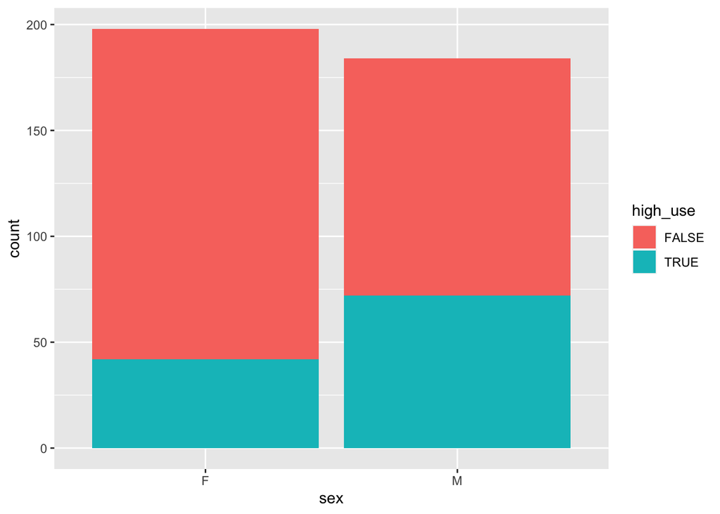

```r
library(ggplot2)

#barplot sex and high use
ggplot(data = alc, aes(x = sex, fill = high_use)) + geom_bar()
```

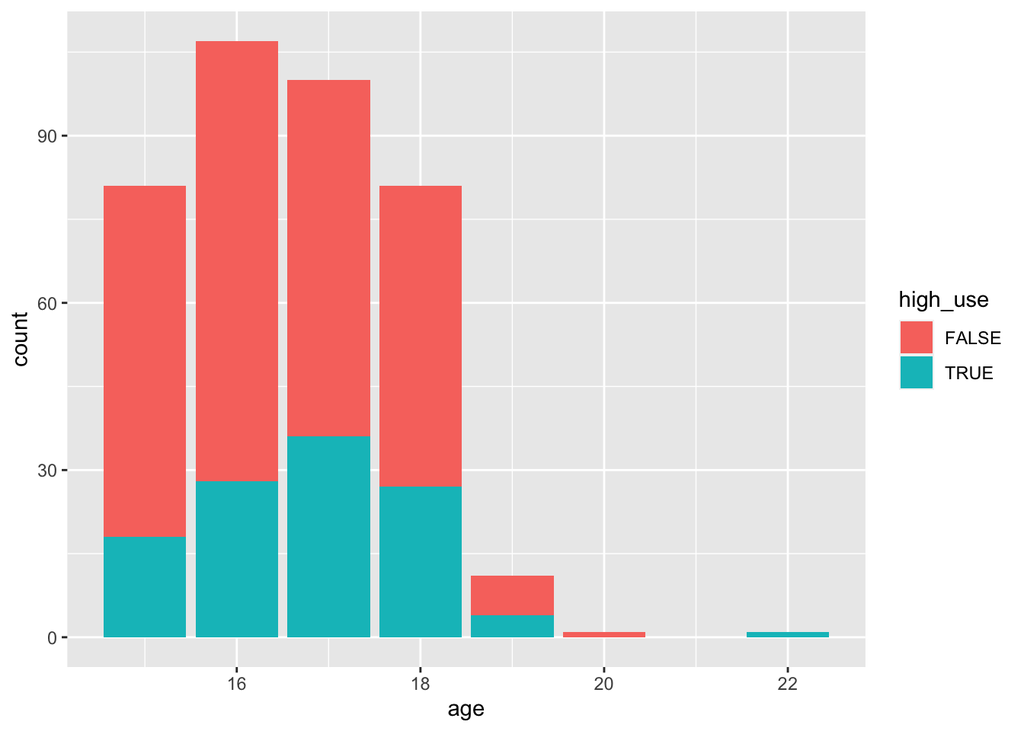

```r
#barplot age and high use
ggplot(data = alc, aes(x = age, fill = high_use)) + geom_bar()
```

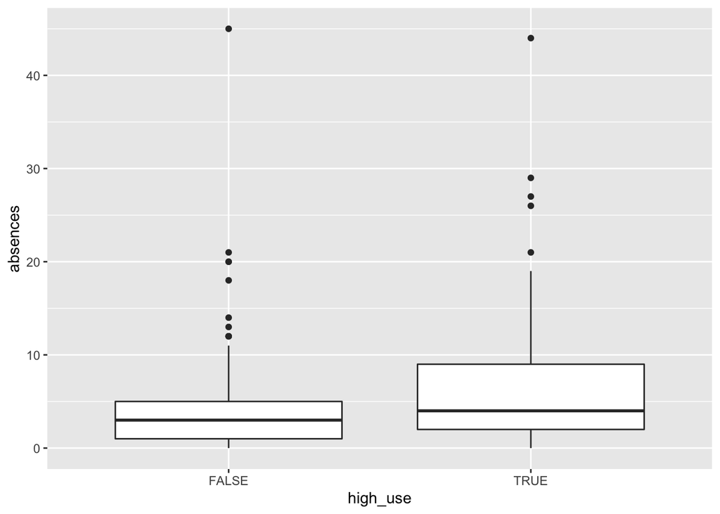

```r
#boxplot absences and high use
ggplot(alc, aes(x = high_use, y = absences)) + geom_boxplot()
```

```r
#cross-tabulation grades and high use
table(highuse = alc$high_use, grades = alc$G3)
```

```
##        grades
## highuse  0  2  3  4  5  6  7  8  9 10 11 12 13 14 15 16 17 18
##   FALSE  1  0  1  6  4 15  4 19  3 38 16 54 19 31 15 30  5  7
##   TRUE   1  1  0  1  2  7  2  8  4 26 10 27  7  7  1  8  2  0
```

From the plots above we can see, that it does seem, that high use is more common among male students compared to female students, but the relationship with high use and age is not clear based on the bar plot. Based on the boxplot it seems, that high use is indeed to some extent related to higher amonts of absences, and based on the cross-tabulation it seems, that students with higher grades are less likely to belong in the group of high users.

```r
# fit the model
model1 <- glm(high_use ~ sex + age + absences + G3, data = alc, family = "binomial")
summary(model1)
```

```
##
## Call:
## glm(formula = high_use ~ sex + age + absences + G3, family = "binomial",
##     data = alc)
##
## Deviance Residuals:
##     Min       1Q   Median       3Q      Max
## -2.2729  -0.8326  -0.6292   1.0442   2.1190
##
## Coefficients:
##             Estimate Std. Error z value Pr(>|z|)
## (Intercept) -3.38339    1.84796  -1.831 0.067120 .
## sexM         0.98580    0.24184   4.076 4.58e-05 ***
## age          0.13985    0.10328   1.354 0.175690
## absences     0.08964    0.02309   3.882 0.000104 ***
## G3          -0.06631    0.03624  -1.830 0.067277 .
## ---
## Signif. codes:  0 '***' 0.001 '**' 0.01 '*' 0.05 '.' 0.1 ' ' 1
##
## (Dispersion parameter for binomial family taken to be 1)
##
##     Null deviance: 465.68  on 381  degrees of freedom
## Residual deviance: 423.66  on 377  degrees of freedom
## AIC: 433.66
##
## Number of Fisher Scoring iterations: 4
```

```r
library(tidyr); library(dplyr)
# compute odds ratios (OR)
OR <- coef(model1) %>% exp

# compute confidence intervals (CI)
CI <- confint(model1) %>% exp
# print out the odds ratios with their confidence intervals
cbind(OR, CI)
```

```
##                     OR        2.5 %   97.5 %
## (Intercept) 0.03393229 0.0008683319 1.237502
## sexM        2.67996134 1.6781593816 4.338864
## age         1.15010522 0.9401979286 1.410759
## absences    1.09377649 1.0474354900 1.146836
## G3          0.93584524 0.8710385897 1.004426
```

Next, we look at the predictive power of the model with only sex and absences as predictors.

```r
library(dplyr)

# fit a new model with only significant predictors
model_pred <- glm(high_use ~ sex + absences, data = alc, family = "binomial")


# predict() the probability of high_use
probabilities <- predict(model_pred, type = "response")

# add the predicted probabilities to 'alc'
alc <- mutate(alc, probability = probabilities)

# use the probabilities to make a prediction of high_use
alc <- mutate(alc, prediction = probability > 0.5)

# tabulate the target variable versus the predictions
table(high_use = alc$high_use, prediction = alc$prediction)
```

```
##         prediction
## high_use FALSE TRUE
##    FALSE   258   10
##    TRUE     88   26
```

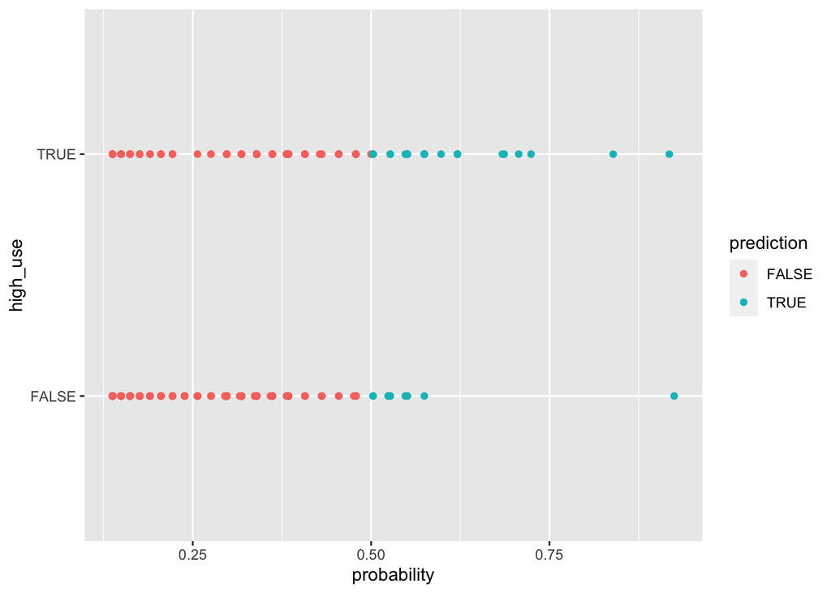

```r
g <- ggplot(alc, aes(x = probability, y = high_use, col = prediction))
g + geom_point()
```